# Extended Data Fig. 16bc: Genome-wide indirect effects

Andreas R. Gschwind

July 23, 2026

```r
library(tidyverse)
library(cowplot)
```

## Goal

Analyze genome-wide indirect effects calculated for all perturbations and genes in the Gasperini et al., 2019 dataset.

## Used data

Load indirect effect rates for all genes and elements in the Gasperini et al., 2019 datasets calculated from sceptre differential expression tests for trans-acting effects of all enhancer perturbations. These are calculated by the code in `DC_TAP_Paper/direct_vs_indirect_effects/genome_wide_indirect_effects`

```r
# files containing indirect effect rates per element and gene
indirect_effects_genes_file <- "../../direct_vs_indirect_effects/genome_wide_indirect_effects/gasperini2019_indirect_effects_per_gene.tsv.gz"
indirect_effects_elements_file <- "../../direct_vs_indirect_effects/genome_wide_indirect_effects/gasperini2019_indirect_effects_per_element.tsv.gz"

# load indirect effect rates per gene
indirect_effects_genes <- read_tsv(indirect_effects_genes_file, show_col_types = FALSE)
indirect_effects_elements <- read_tsv(indirect_effects_elements_file, show_col_types = FALSE)

# output directory for generated plots
outdir <- "../extended_data_figure_16"
```

## Indirect effects vs. TPM

Plot relationship between indirect effect rate vs. target gene TPM.

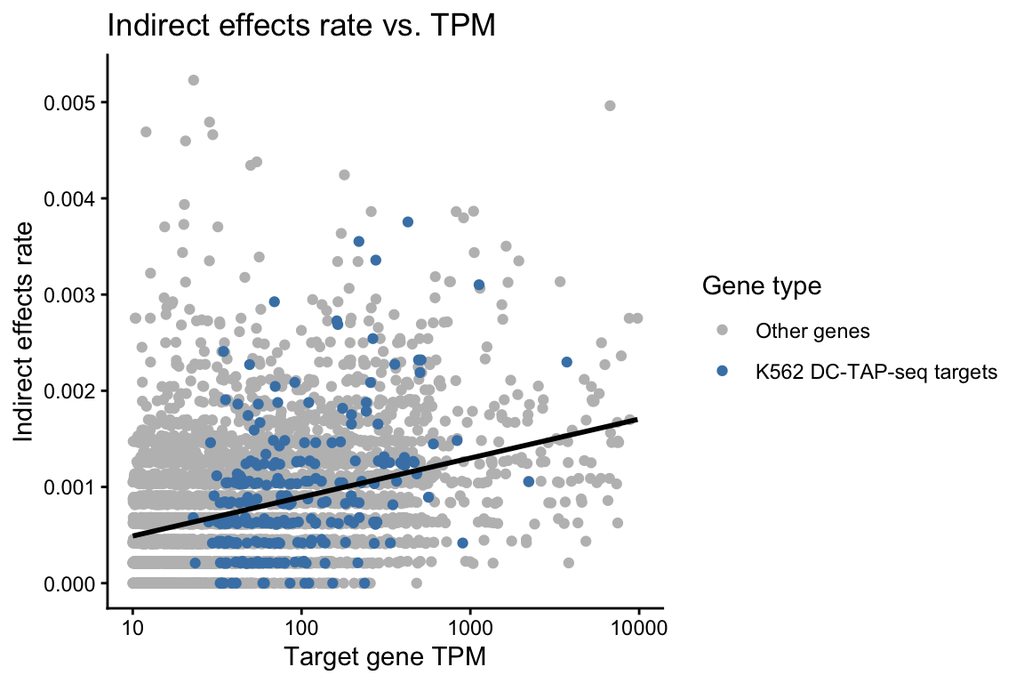

```r
# create plotting labels for genes in K562 DC-TAP-seq target gene panels
indirect_effects_genes <- indirect_effects_genes %>%
  mutate(dc_tap_group = if_else(k562_dc_tap_gene == TRUE, true = "K562 DC-TAP-seq targets",
                                false = "Other genes")) %>%
  mutate(dc_tap_group = fct_relevel(dc_tap_group, "Other genes")) %>%
  arrange(dc_tap_group)

# filter for genes within custom TPM range for plot
indirect_effects_tpm_range <- indirect_effects_genes %>%
  filter(tpm >= 10, tpm <= 1e4)

# plot indirect effects rate vs target gene TPM
ggplot(indirect_effects_tpm_range, aes(x = tpm, y = trans_hit_rate, color = dc_tap_group)) +
  geom_point() +
  geom_smooth(aes(group = 1), method = "lm", se = FALSE, color = "black") +
  labs(title = "Indirect effects rate vs. TPM", x = "Target gene TPM",
       y = "Indirect effects rate", color = "Gene type") +
  scale_color_manual(values = c("K562 DC-TAP-seq targets" = "steelblue", "Other genes" = "gray")) +
  scale_x_log10() +
  theme_classic()
```

The positive relationship between the observed indirect effects rate and target gene expression level is likely driven by higher statistical power to detect differential expression effects for genes with higher UMI counts.

Therefore to compare indirect effect rates between DC-TAP-seq target genes and other genes, we need to match TPM distributions of the two groups.

## Compare indirect effects

Compare indirect effects rates between K562 DC-TAP-seq target genes versus a sample of other genes expressed with similar TPM distribution.

```r
# split genes into the two groups to compare
target_genes <- filter(indirect_effects_genes, k562_dc_tap_gene == TRUE)
other_genes  <- filter(indirect_effects_genes, k562_dc_tap_gene == FALSE)

# restrict other genes to the TPM range spanned by the DC TAP-seq target genes, so the matched
# sample can only contain genes expressed within that range
tpm_range <- range(target_genes$tpm)
other_genes <- filter(other_genes, tpm >= tpm_range[1], tpm <= tpm_range[2])

# define TPM bins (log10 scale) from deciles of the target genes' TPM distribution; the outer
# breaks equal the min/max target TPM, which now also bound the other genes
tpm_breaks <- quantile(log10(target_genes$tpm), probs = seq(0, 1, length.out = 11))

target_genes <- mutate(target_genes, tpm_bin = cut(log10(tpm), tpm_breaks, include.lowest = TRUE))
other_genes  <- mutate(other_genes,  tpm_bin = cut(log10(tpm), tpm_breaks, include.lowest = TRUE))

# number and proportion of target genes per TPM bin (the TPM distribution to match), plus the number
# of other genes available in each bin
n_per_bin <- target_genes %>%
  count(tpm_bin, name = "n_target") %>%
  mutate(prop_target = n_target / sum(n_target)) %>%
  left_join(count(other_genes, tpm_bin, name = "n_other_avail"), by = "tpm_bin") %>%
  mutate(n_other_avail = coalesce(n_other_avail, 0L))

# sample as many "Other genes" as possible while keeping their per-bin proportions identical to the
# target genes' TPM distribution. The largest achievable total is set by the bin that runs out of
# available genes first: scale each bin's target proportion up by the maximum factor for which no bin
# exceeds its available genes, then take that many per bin.
scale_factor <- min(n_per_bin$n_other_avail / n_per_bin$prop_target)
n_per_bin <- mutate(n_per_bin, n_other = floor(scale_factor * prop_target))

# sample the computed number of "Other genes" per TPM bin
set.seed(20260710)
matched_other_genes <- other_genes %>%
  group_by(tpm_bin) %>%
  group_modify(~ slice_sample(.x, n = n_per_bin$n_other[n_per_bin$tpm_bin == .y$tpm_bin])) %>%
  ungroup()

# combine target genes with the TPM-matched sample of other genes
indirect_effects_tpm_matched <- bind_rows(target_genes, matched_other_genes)
```

Sanity check: the TPM distributions of the two groups should overlap after matching.

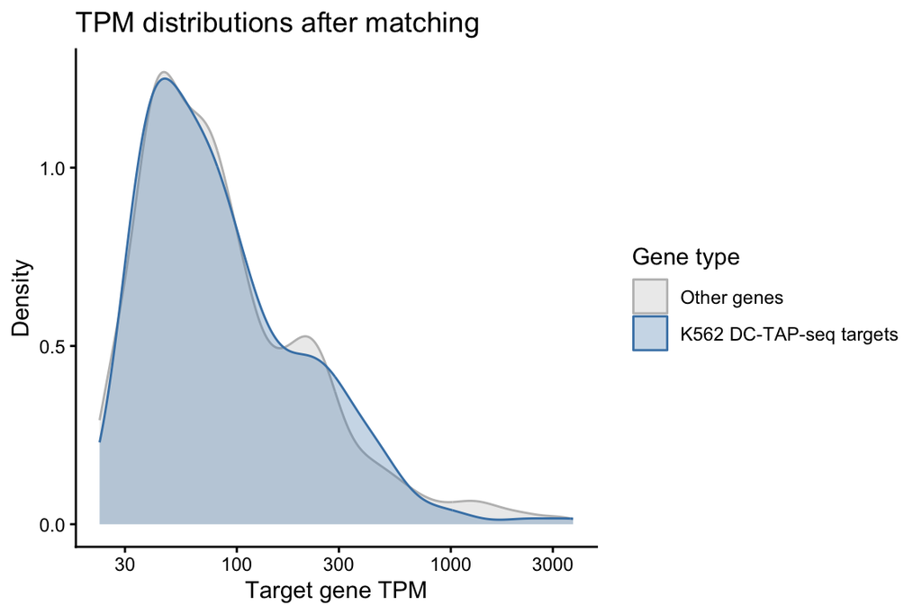

```r
# plot TPM density of both groups to confirm the matching worked
ggplot(indirect_effects_tpm_matched, aes(x = tpm, fill = dc_tap_group, color = dc_tap_group)) +
  geom_density(alpha = 0.3) +
  labs(title = "TPM distributions after matching", x = "Target gene TPM", y = "Density",
       fill = "Gene type", color = "Gene type") +
  scale_color_manual(values = c("K562 DC-TAP-seq targets" = "steelblue", "Other genes" = "gray")) +
  scale_fill_manual(values = c("K562 DC-TAP-seq targets" = "steelblue", "Other genes" = "gray")) +
  scale_x_log10() +
  theme_classic()
```

```r
# test for a difference in indirect effect rates between the two groups. The groups are independent
# and the rates are non-normal, so use a two-sided Wilcoxon rank-sum (Mann-Whitney U) test
rate_test <- wilcox.test(trans_hit_rate ~ dc_tap_group, data = indirect_effects_tpm_matched)
rate_test
```

```
##
##  Wilcoxon rank sum test with continuity correction
##
## data:  trans_hit_rate by dc_tap_group
## W = 286821, p-value = 0.4898
## alternative hypothesis: true location shift is not equal to 0
```

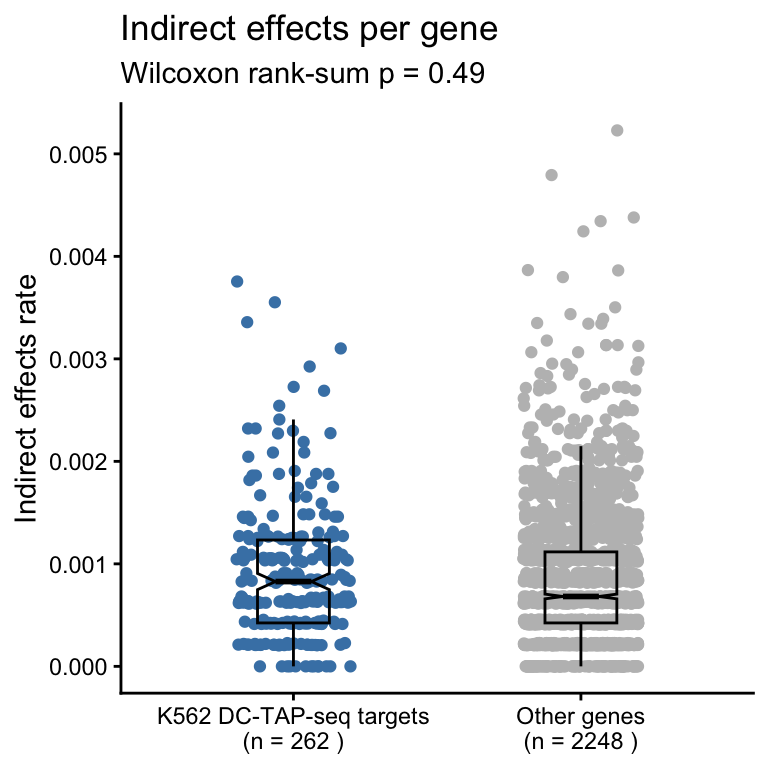

```r
# add sample sizes to labels
indirect_effects_tpm_matched <- indirect_effects_tpm_matched %>%
  add_count(k562_dc_tap_gene, name = "n") %>%
  mutate(dc_tap_group = paste0(dc_tap_group, "\n(n = ", n, " )" ))

# compare indirect effect rates between K562 target genes any other 30+ TPM genes
p1 <- ggplot(indirect_effects_tpm_matched,
             aes(x = dc_tap_group, y = trans_hit_rate, color = dc_tap_group)) +
  geom_jitter(width = 0.2) +
  geom_boxplot(outlier.shape = NA, fill = NA, color = "black", width = 0.25, notch = TRUE) +
  labs(y = "Indirect effects rate", title = "Indirect effects per gene",
       subtitle = paste0("Wilcoxon rank-sum p = ", signif(rate_test$p.value, 2))) +
  scale_color_manual(values = c("steelblue", "gray")) +
  theme_classic() +
  theme(legend.position = "none", axis.title.x = element_blank())

p1
```

## Per-element indirect effect rates

```r
# test for a difference in indirect effect rates between the two groups. The groups are independent
# and the rates are non-normal, so use a two-sided Wilcoxon rank-sum (Mann-Whitney U) test
rate_test <- wilcox.test(trans_hit_rate ~ k562_dc_tap_element, data = indirect_effects_elements)
rate_test
```

```
##
##  Wilcoxon rank sum test with continuity correction
##
## data:  trans_hit_rate by k562_dc_tap_element
## W = 124626, p-value = 0.1634
## alternative hypothesis: true location shift is not equal to 0
```

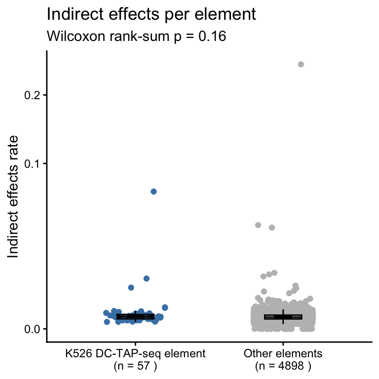

```r
# add new labels for elements
indirect_effects_elements <- indirect_effects_elements %>%
  mutate(element_group = if_else(k562_dc_tap_element == TRUE, true = "K526 DC-TAP-seq element",
                                 false = "Other elements")) %>%
  add_count(k562_dc_tap_element, name = "n") %>%
  mutate(element_group = paste0(element_group, "\n(n = ", n, " )" ))

# make plot
p2 <- ggplot(indirect_effects_elements,
             aes(x = element_group, y = trans_hit_rate, color = element_group)) +
  geom_jitter(width = 0.2) +
  geom_boxplot(outlier.shape = NA, fill = NA, color = "black", width = 0.25, notch = TRUE) +
  labs(y = "Indirect effects rate", title = "Indirect effects per element",
       subtitle = paste0("Wilcoxon rank-sum p = ", signif(rate_test$p.value, 2))) +
  scale_y_sqrt() +
  scale_color_manual(values = c("steelblue", "gray")) +
  theme_classic() +
  theme(legend.position = "none", axis.title.x = element_blank())

p2
```

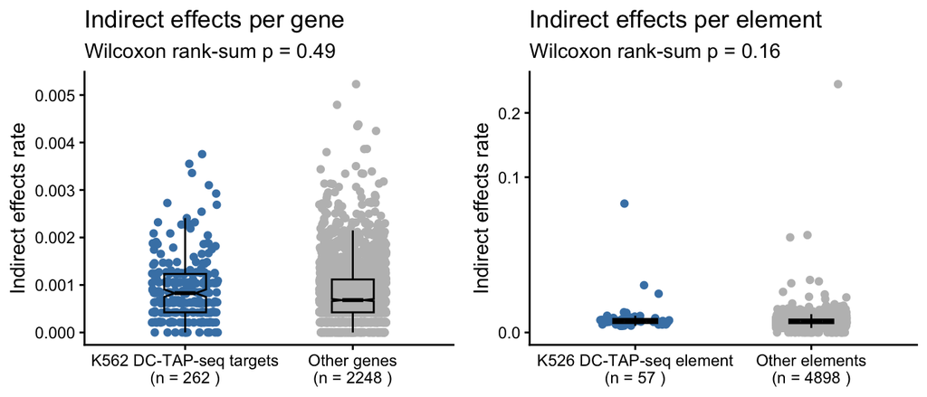

```r
# arrange plots into figure
plot_grid(p1, p2, nrow = 1)
```

```r
ggsave(filename = "ExtData_Fig16bc_indirect_rates_gasperini.pdf", height = 3, width = 7)
```